# 공간가중패널회귀

202202366 이나원

2024-05-26

## 최근거리 설정방법

# 패키지 불러오기

```r
library(plm)
library(sf)
library(spdep)
library(splm)
library(dplyr)
library(geosphere)
library(sp)
```

# 데이터 불러오기

```r
location <- read.csv('./location.csv')
location <- na.omit(location)
head(location)
```

```
##   city code longitude latitude
## 1 고양  540  126.7771 37.65591
## 2 고흥  262  127.2871 34.60807
## 3 공주  612  127.1211 36.44361
## 4 김제  737  126.8828 35.80058
## 5 김포  441  126.7178 37.61246
## 6 논산  615  127.1009 36.18420
```

```r
data <- read.csv('./SARdata.csv')
head(data)
```

```
##   지역코드 연도 X4월.평균기온... X4월.평균최고기온... X9월.강수량.mm.
## 1       95 2013              8.1                 14.4           153.4
## 2       95 2014             12.3                 20.0            73.0
## 3       95 2015             11.3                 18.5            32.7
## 4       95 2016             12.6                 20.0            32.2
## 5       95 2017             12.1                 19.3            26.6
## 6       95 2018             11.2                 17.9            55.4
##   X7월.합계.일조시간.hr. X11월.평균.지면온도..C. 생산량
## 1                  115.9                     3.6    463
## 2                  207.1                     4.0    594
## 3                  197.7                     5.8    572
## 4                  153.9                     7.4    576
## 5                  119.9                     6.1    522
## 6                  234.6                     4.2    573
```

```r
data$x <- location$longitude
data$y <- location$latitude
head(data)
```

```
##   지역코드 연도 X4월.평균기온... X4월.평균최고기온... X9월.강수량.mm.
## 1       95 2013              8.1                 14.4           153.4
## 2       95 2014             12.3                 20.0            73.0
## 3       95 2015             11.3                 18.5            32.7
## 4       95 2016             12.6                 20.0            32.2
## 5       95 2017             12.1                 19.3            26.6
## 6       95 2018             11.2                 17.9            55.4
##   X7월.합계.일조시간.hr. X11월.평균.지면온도..C. 생산량        x        y
## 1                  115.9                     3.6    463 126.7771 37.65591
## 2                  207.1                     4.0    594 127.2871 34.60807
## 3                  197.7                     5.8    572 127.1211 36.44361
## 4                  153.9                     7.4    576 126.8828 35.80058
## 5                  119.9                     6.1    522 126.7178 37.61246
## 6                  234.6                     4.2    573 127.1009 36.18420
```

```r
write.csv(data, file = "output.csv", row.names = FALSE)
```

```r
names(data)
```

```
##  [1] "지역코드"                "연도"
##  [3] "X4월.평균기온..."        "X4월.평균최고기온..."
##  [5] "X9월.강수량.mm."         "X7월.합계.일조시간.hr."
##  [7] "X11월.평균.지면온도..C." "생산량"
##  [9] "x"                       "y"
```

# 가중치행렬계산 m=3

```r
# 위치 데이터를 SpatialPoints 객체로 변환
coordinates_data <- location[, c("longitude", "latitude")]
spatial_data <- SpatialPoints(coords = coordinates_data,proj4string = CRS("+proj=tmerc +lat_0=38 +lon_0=127 +k=1 +x_0=200000 +y_0=500000 +ellps=GRS80 +units=m +no_defs"))
# TM 중부 원점 좌표계로 변환 (EPSG:5179)
spatial_data <- spTransform(spatial_data,CRS("+init=epsg:5179"))
# 각 위치 간의 거리 계산
distances <- spDists(spatial_data)

# 가장 가까운 m개의 이웃 선택
m <- 3
nearest_neighbors <- matrix(0, nrow = nrow(distances), ncol = m)
for (i in 1:nrow(distances)) {
  nearest_neighbors[i, ] <- order(distances[i, ])[2:(m+1)]
}

# 가중치 행렬 생성
weight_matrix_m3 <- matrix(0, nrow = nrow(location), ncol = nrow(location))
for (i in 1:nrow(nearest_neighbors)) {
  weight_matrix_m3[i, nearest_neighbors[i, ]] <- 1 / distances[i, nearest_neighbors[i, ]]
}

# 표준화
for (i in 1:nrow(weight_matrix_m3)) {
  weight_matrix_m3[i, ] <- weight_matrix_m3[i, ] / sum(weight_matrix_m3[i, ])
}


# 행렬 출력
rownames(weight_matrix_m3) <- location$city
colnames(weight_matrix_m3) <- location$city
head(weight_matrix_m3)
```

```
##           고양 고흥      공주 김제      김포      논산 당신 서산      서천 양구
## 고양 0.0000000    0 0.0000000    0 0.5306517 0.0000000    0    0 0.0000000    0
## 고흥 0.0000000    0 0.0000000    0 0.0000000 0.0000000    0    0 0.0000000    0
## 공주 0.0000000    0 0.0000000    0 0.0000000 0.4252006    0    0 0.0000000    0
## 김제 0.0000000    0 0.0000000    0 0.0000000 0.0000000    0    0 0.2237151    0
## 김포 0.6116751    0 0.0000000    0 0.0000000 0.0000000    0    0 0.0000000    0
## 논산 0.0000000    0 0.3912177    0 0.0000000 0.0000000    0    0 0.2419051    0
##      양양 양평 여주      예산 용인 이천      익산 인제 정선      정읍    진도
## 고양    0    0    0 0.0000000    0    0 0.0000000    0    0 0.0000000 0.00000
## 고흥    0    0    0 0.0000000    0    0 0.0000000    0    0 0.2816812 0.28752
## 공주    0    0    0 0.3082528    0    0 0.0000000    0    0 0.0000000 0.00000
## 김제    0    0    0 0.0000000    0    0 0.4572562    0    0 0.3190287 0.00000
## 김포    0    0    0 0.0000000    0    0 0.0000000    0    0 0.0000000 0.00000
## 논산    0    0    0 0.0000000    0    0 0.3668772    0    0 0.0000000 0.00000
##      진천 철원      청주      파주 평택 포천 포항      해남       화성 화천
## 고양    0    0 0.0000000 0.3850311    0    0    0 0.0000000 0.08431724    0
## 고흥    0    0 0.0000000 0.0000000    0    0    0 0.4307988 0.00000000    0
## 공주    0    0 0.2665465 0.0000000    0    0    0 0.0000000 0.00000000    0
## 김제    0    0 0.0000000 0.0000000    0    0    0 0.0000000 0.00000000    0
## 김포    0    0 0.0000000 0.2841294    0    0    0 0.0000000 0.10419553    0
## 논산    0    0 0.0000000 0.0000000    0    0    0 0.0000000 0.00000000    0
```

# 가중치행렬계산 m=4

```r
# 위치 데이터를 SpatialPoints 객체로 변환
coordinates_data <- location[, c("longitude", "latitude")]
spatial_data <- SpatialPoints(coords = coordinates_data,proj4string = CRS("+proj=tmerc +lat_0=38 +lon_0=127 +k=1 +x_0=200000 +y_0=500000 +ellps=GRS80 +units=m +no_defs"))
# TM 중부 원점 좌표계로 변환 (EPSG:5179)
spatial_data <- spTransform(spatial_data,CRS("+init=epsg:5179"))
# 각 위치 간의 거리 계산
distances <- spDists(spatial_data)

# 가장 가까운 m개의 이웃 선택
m <- 4
nearest_neighbors <- matrix(0, nrow = nrow(distances), ncol = m)
for (i in 1:nrow(distances)) {
  nearest_neighbors[i, ] <- order(distances[i, ])[2:(m+1)]
}

# 가중치 행렬 생성
weight_matrix_m4 <- matrix(0, nrow = nrow(location), ncol = nrow(location))
for (i in 1:nrow(nearest_neighbors)) {
  weight_matrix_m4[i, nearest_neighbors[i, ]] <- 1 / distances[i, nearest_neighbors[i, ]]
}

# 표준화
for (i in 1:nrow(weight_matrix_m4)) {
  weight_matrix_m4[i, ] <- weight_matrix_m4[i, ] / sum(weight_matrix_m4[i, ])
}


# 행렬 출력
rownames(weight_matrix_m4) <- location$city
colnames(weight_matrix_m4) <- location$city
head(weight_matrix_m4)
```

```
##           고양 고흥      공주      김제      김포      논산 당신 서산      서천
## 고양 0.0000000    0 0.0000000 0.0000000 0.4912733 0.0000000    0    0 0.0000000
## 고흥 0.0000000    0 0.0000000 0.1902652 0.0000000 0.0000000    0    0 0.0000000
## 공주 0.0000000    0 0.0000000 0.0000000 0.0000000 0.3502625    0    0 0.0000000
## 김제 0.0000000    0 0.0000000 0.0000000 0.0000000 0.1452111    0    0 0.1912292
## 김포 0.5661866    0 0.0000000 0.0000000 0.0000000 0.0000000    0    0 0.0000000
## 논산 0.0000000    0 0.3178933 0.1874261 0.0000000 0.0000000    0    0 0.1965658
##      양구 양양 양평 여주      예산 용인 이천      익산 인제 정선      정읍
## 고양    0    0    0    0 0.0000000    0    0 0.0000000    0    0 0.0000000
## 고흥    0    0    0    0 0.0000000    0    0 0.0000000    0    0 0.2280870
## 공주    0    0    0    0 0.2539258    0    0 0.0000000    0    0 0.0000000
## 김제    0    0    0    0 0.0000000    0    0 0.3908575    0    0 0.2727022
## 김포    0    0    0    0 0.0000000    0    0 0.0000000    0    0 0.0000000
## 논산    0    0    0    0 0.0000000    0    0 0.2981149    0    0 0.0000000
##          진도      진천 철원      청주      파주 평택       포천 포항      해남
## 고양 0.000000 0.0000000    0 0.0000000 0.3564589    0 0.07420761    0 0.0000000
## 고흥 0.232815 0.0000000    0 0.0000000 0.0000000    0 0.00000000    0 0.3488328
## 공주 0.000000 0.1762418    0 0.2195699 0.0000000    0 0.00000000    0 0.0000000
## 김제 0.000000 0.0000000    0 0.0000000 0.0000000    0 0.00000000    0 0.0000000
## 김포 0.000000 0.0000000    0 0.0000000 0.2629996    0 0.07436698    0 0.0000000
## 논산 0.000000 0.0000000    0 0.0000000 0.0000000    0 0.00000000    0 0.0000000
##            화성 화천
## 고양 0.07806026    0
## 고흥 0.00000000    0
## 공주 0.00000000    0
## 김제 0.00000000    0
## 김포 0.09644682    0
## 논산 0.00000000    0
```

# 가중치행렬계산 m=5

```r
# 위치 데이터를 SpatialPoints 객체로 변환
coordinates_data <- location[, c("longitude", "latitude")]
spatial_data <- SpatialPoints(coords = coordinates_data,proj4string = CRS("+proj=tmerc +lat_0=38 +lon_0=127 +k=1 +x_0=200000 +y_0=500000 +ellps=GRS80 +units=m +no_defs"))
# TM 중부 원점 좌표계로 변환 (EPSG:5179)
spatial_data <- spTransform(spatial_data,CRS("+init=epsg:5179"))
# 각 위치 간의 거리 계산
distances <- spDists(spatial_data)

# 가장 가까운 m개의 이웃 선택
m <- 5
nearest_neighbors <- matrix(0, nrow = nrow(distances), ncol = m)
for (i in 1:nrow(distances)) {
  nearest_neighbors[i, ] <- order(distances[i, ])[2:(m+1)]
}

# 가중치 행렬 생성
weight_matrix_m5 <- matrix(0, nrow = nrow(location), ncol = nrow(location))
for (i in 1:nrow(nearest_neighbors)) {
  weight_matrix_m5[i, nearest_neighbors[i, ]] <- 1 / distances[i, nearest_neighbors[i, ]]
}

# 표준화
for (i in 1:nrow(weight_matrix_m5)) {
  weight_matrix_m5[i, ] <- weight_matrix_m5[i, ] / sum(weight_matrix_m5[i, ])
}


# 행렬 출력
rownames(weight_matrix_m5) <- location$city
colnames(weight_matrix_m5) <- location$city
head(weight_matrix_m5)
```

```
##           고양 고흥       공주      김제      김포      논산 당신 서산
## 고양 0.0000000    0 0.00000000 0.0000000 0.4634707 0.0000000    0    0
## 고흥 0.0000000    0 0.00000000 0.1620618 0.0000000 0.0000000    0    0
## 공주 0.0000000    0 0.00000000 0.0000000 0.0000000 0.2983501    0    0
## 김제 0.0000000    0 0.08545955 0.0000000 0.0000000 0.1328014    0    0
## 김포 0.5304451    0 0.00000000 0.0000000 0.0000000 0.0000000    0    0
## 논산 0.0000000    0 0.27666759 0.1631199 0.0000000 0.0000000    0    0
##           서천 양구 양양 양평 여주      예산       용인 이천      익산 인제
## 고양 0.0000000    0    0    0    0 0.0000000 0.05659288    0 0.0000000    0
## 고흥 0.0000000    0    0    0    0 0.0000000 0.00000000    0 0.1482322    0
## 공주 0.0000000    0    0    0    0 0.2162915 0.00000000    0 0.1482099    0
## 김제 0.1748869    0    0    0    0 0.0000000 0.00000000    0 0.3574550    0
## 김포 0.0000000    0    0    0    0 0.0000000 0.06312680    0 0.0000000    0
## 논산 0.1710743    0    0    0    0 0.1296840 0.00000000    0 0.2594541    0
##      정선      정읍      진도      진천 철원      청주      파주 평택
## 고양    0 0.0000000 0.0000000 0.0000000    0 0.0000000 0.3362858    0
## 고흥    0 0.1942772 0.1983043 0.0000000    0 0.0000000 0.0000000    0
## 공주    0 0.0000000 0.0000000 0.1501211    0 0.1870275 0.0000000    0
## 김제    0 0.2493972 0.0000000 0.0000000    0 0.0000000 0.0000000    0
## 김포    0 0.0000000 0.0000000 0.0000000    0 0.0000000 0.2463972    0
## 논산    0 0.0000000 0.0000000 0.0000000    0 0.0000000 0.0000000    0
##            포천 포항      해남       화성 화천
## 고양 0.07000799    0 0.0000000 0.07364261    0
## 고흥 0.00000000    0 0.2971245 0.00000000    0
## 공주 0.00000000    0 0.0000000 0.00000000    0
## 김제 0.00000000    0 0.0000000 0.00000000    0
## 김포 0.06967243    0 0.0000000 0.09035844    0
## 논산 0.00000000    0 0.0000000 0.00000000    0
```

# 하우스만 검정 : p-value가 0.05보다 작으면 고정효과 모델 사용

- m=3 일 때 하우스만 검정

```r
library(plm)
# 공간 가중 행렬을 listw 객체로 변환
listw <- mat2listw(weight_matrix_m3, style = "W")

data$id <- as.factor(data$지역코드)  # 지역 코드를 패널 ID로 설정
data$time <- as.factor(data$연도)    # 연도를 시간 변수로 설정
# 패널 데이터로 변환
panel_data <- pdata.frame(data, index = c("id", "time"))

# 종속 변수와 독립 변수 설정
# 예제에서는 논벼 10a당 생산량을 종속 변수로, 기온, 강수량, 일조시간, 지면온도를 독립 변수로 사용합니다.
panel_data$생산량 <- data$생산량
panel_data$기온 <- data$X4월.평균기온...
panel_data$최고기온 <- data$X4월.평균최고기온...
panel_data$강수량 <- data$X9월.강수량.mm.
panel_data$일조시간 <- data$X7월.합계.일조시간.hr.
panel_data$지면온도 <- data$X11월.평균.지면온도..C.

# 고정 효과 모델을 적합합니다
fixed_model <- spml(생산량 ~ 기온 + 최고기온 + 강수량 + 일조시간 + 지면온도,
                      data = panel_data,
                      listw = listw,
                      model = "within",
                      lag = TRUE)

# 랜덤 효과 모델을 적합합니다
random_model <- spml(생산량 ~ 기온 + 최고기온 + 강수량 + 일조시간 + 지면온도,
                      data = panel_data,
                      listw = listw,
                      model = "random",
                      lag = TRUE)

# 하우스만 검정을 수행합니다
hausman_test <- sphtest(fixed_model, random_model)
print(hausman_test)
```

```
##
##  Hausman test for spatial models
##
## data:  생산량 ~ 기온 + 최고기온 + 강수량 + 일조시간 +     지면온도
## chisq = 10.073, df = 5, p-value = 0.0732
## alternative hypothesis: one model is inconsistent
```

해석: 유의수준 0.05에서 검정 결과, p-value가 0.0732로 귀무 가설을 기각할 충분한 증거가 없다. 따라서 랜뎜 효과 모형을 쓰는 것이 적절할 것이다.

- m=4

```r
library(plm)
# 공간 가중 행렬을 listw 객체로 변환
listw <- mat2listw(weight_matrix_m4, style = "W")

data$id <- as.factor(data$지역코드)  # 지역 코드를 패널 ID로 설정
data$time <- as.factor(data$연도)    # 연도를 시간 변수로 설정
# 패널 데이터로 변환
panel_data <- pdata.frame(data, index = c("id", "time"))

# 종속 변수와 독립 변수 설정
# 예제에서는 논벼 10a당 생산량을 종속 변수로, 기온, 강수량, 일조시간, 지면온도를 독립 변수로 사용합니다.
panel_data$생산량 <- data$생산량
panel_data$기온 <- data$X4월.평균기온...
panel_data$최고기온 <- data$X4월.평균최고기온...
panel_data$강수량 <- data$X9월.강수량.mm.
panel_data$일조시간 <- data$X7월.합계.일조시간.hr.
panel_data$지면온도 <- data$X11월.평균.지면온도..C.

#  효과 모델을 적합합니다
fixed_model <- spml(생산량 ~ 기온 + 최고기온 + 강수량 + 일조시간 + 지면온도,
                      data = panel_data,
                      listw = listw,
                      model = "within",
                      lag = TRUE)

# 랜덤 효과 모델을 적합합니다
random_model <- spml(생산량 ~ 기온 + 최고기온 + 강수량 + 일조시간 + 지면온도,
                      data = panel_data,
                      listw = listw,
                      model = "random",
                      lag = TRUE)

# 하우스만 검정을 수행합니다
hausman_test <- sphtest(fixed_model, random_model)
print(hausman_test)
```

```
##
##  Hausman test for spatial models
##
## data:  생산량 ~ 기온 + 최고기온 + 강수량 + 일조시간 +     지면온도
## chisq = 15.003, df = 5, p-value = 0.01035
## alternative hypothesis: one model is inconsistent
```

- m = 5 하우스만 검정 결과

```r
library(plm)
# 공간 가중 행렬을 listw 객체로 변환
listw <- mat2listw(weight_matrix_m5, style = "W")

data$id <- as.factor(data$지역코드)  # 지역 코드를 패널 ID로 설정
data$time <- as.factor(data$연도)    # 연도를 시간 변수로 설정
# 패널 데이터로 변환
panel_data <- pdata.frame(data, index = c("id", "time"))

# 종속 변수와 독립 변수 설정
# 예제에서는 논벼 10a당 생산량을 종속 변수로, 기온, 강수량, 일조시간, 지면온도를 독립 변수로 사용합니다.
panel_data$생산량 <- data$생산량
panel_data$기온 <- data$X4월.평균기온...
panel_data$최고기온 <- data$X4월.평균최고기온...
panel_data$강수량 <- data$X9월.강수량.mm.
panel_data$일조시간 <- data$X7월.합계.일조시간.hr.
panel_data$지면온도 <- data$X11월.평균.지면온도..C.

# 고정 효과 모델을 적합합니다
fixed_model <- spml(생산량 ~ 기온 + 최고기온 + 강수량 + 일조시간 + 지면온도,
                      data = panel_data,
                      listw = listw,
                      model = "within",
                      lag = TRUE)

# 랜덤 효과 모델을 적합합니다
random_model <- spml(생산량 ~ 기온 + 최고기온 + 강수량 + 일조시간 + 지면온도,
                      data = panel_data,
                      listw = listw,
                      model = "random",
                      lag = TRUE)

# 하우스만 검정을 수행합니다
hausman_test <- sphtest(fixed_model, random_model)
print(hausman_test)
```

```
##
##  Hausman test for spatial models
##
## data:  생산량 ~ 기온 + 최고기온 + 강수량 + 일조시간 +     지면온도
## chisq = 15.864, df = 5, p-value = 0.007243
## alternative hypothesis: one model is inconsistent
```

- 하우스만 검정 결과 m=3 에서 랜덤효과, m=4,5에서 고정효과 모형을 쓰는 것이 더 적절하다고 판정이 되었다.

# 패널 데이터 설정 및 공간 회귀 분석 - 랜덤효과 (m=3)

```r
# 공간 가중 행렬을 listw 객체로 변환
listw <- mat2listw(weight_matrix_m3, style = "W")

# 공간 패널 회귀 모델 생성 및 적합
# 예제에서는 Spatial Lag Model (SAR) 모델을 사용합니다.
random_effects_model_m3 <- spml(생산량 ~ 기온 + 최고기온 + 강수량 + 일조시간 + 지면온도,
                      data = panel_data,
                      listw = listw,
                      model = "random",
                      lag = TRUE)

# 모델 요약
summary(random_effects_model_m3)
```

```
## ML panel with spatial lag, random effects, spatial error correlation
##
## Call:
## spreml(formula = formula, data = data, index = index, w = listw2mat(listw),
##     w2 = listw2mat(listw2), lag = lag, errors = errors, cl = cl)
##
## Residuals:
##    Min. 1st Qu.  Median    Mean 3rd Qu.    Max.
##    19.6   111.8   137.8   139.5   167.6   232.7
##
## Error variance parameters:
##      Estimate Std. Error t-value Pr(>|t|)
## phi  1.783409   0.575298  3.1000 0.001935 **
## rho -0.018759   0.312178 -0.0601 0.952084
##
## Spatial autoregressive coefficient:
##        Estimate Std. Error t-value Pr(>|t|)
## lambda  0.27093    0.21909  1.2366   0.2162
##
## Coefficients:
##               Estimate Std. Error t-value  Pr(>|t|)
## (Intercept) 292.824119  16.163220 18.1167 < 2.2e-16 ***
## 기온          2.767886   2.140746  1.2930 0.1960270
## 최고기온      1.351513   1.589965  0.8500 0.3953103
## 강수량       -0.073258   0.017299 -4.2349 2.287e-05 ***
## 일조시간      0.104940   0.031108  3.3734 0.0007424 ***
## 지면온도      1.746259   1.136732  1.5362 0.1244869
## ---
## Signif. codes:  0 '***' 0.001 '**' 0.01 '*' 0.05 '.' 0.1 ' ' 1
```

- 기온, 최고기온, 지면 온도 제외 후 다시 시행

```r
# 공간 가중 행렬을 listw 객체로 변환
listw <- mat2listw(weight_matrix_m3, style = "W")

# 공간 패널 회귀 모델 생성 및 적합
# 예제에서는 Spatial Lag Model (SAR) 모델을 사용합니다.
model_m3 <- spml(생산량 ~ 강수량 + 일조시간,
                      data = panel_data,
                      listw = listw,
                      model = "random",
                      lag = TRUE)

# 모델 요약
summary(model_m3)
```

```
## ML panel with spatial lag, random effects, spatial error correlation
##
## Call:
## spreml(formula = formula, data = data, index = index, w = listw2mat(listw),
##     w2 = listw2mat(listw2), lag = lag, errors = errors, cl = cl)
##
## Residuals:
##    Min. 1st Qu.  Median    Mean 3rd Qu.    Max.
##      93     197     226     227     256     324
##
## Error variance parameters:
##     Estimate Std. Error t-value Pr(>|t|)
## phi  1.94017    0.58073  3.3409 0.000835 ***
## rho -0.15722    0.16396 -0.9589 0.337622
##
## Spatial autoregressive coefficient:
##        Estimate Std. Error t-value  Pr(>|t|)
## lambda  0.44001    0.10588  4.1558 3.242e-05 ***
##
## Coefficients:
##               Estimate Std. Error t-value  Pr(>|t|)
## (Intercept) 274.204198   7.590098 36.1266 < 2.2e-16 ***
## 강수량       -0.078337   0.015652 -5.0050 5.586e-07 ***
## 일조시간      0.129187   0.024941  5.1796 2.224e-07 ***
## ---
## Signif. codes:  0 '***' 0.001 '**' 0.01 '*' 0.05 '.' 0.1 ' ' 1
```

# 패널 데이터 설정 및 공간 회귀 분석 - 고정효과 (m=4)

```r
# 공간 가중 행렬을 listw 객체로 변환
listw <- mat2listw(weight_matrix_m4, style = "W")

# 공간 패널 회귀 모델 생성 및 적합
# 예제에서는 Spatial Lag Model (SAR) 모델을 사용합니다.
fixed_effects_model_m4 <- spml(생산량 ~ 기온 + 최고기온 + 강수량 + 일조시간 + 지면온도,
                      data = panel_data,
                      listw = listw,
                      model = "within",
                      lag = TRUE)

# 모델 요약
summary(fixed_effects_model_m4)
```

```
## Spatial panel fixed effects sarar model
##
##
## Call:
## spml(formula = 생산량 ~ 기온 + 최고기온 + 강수량 +
##     일조시간 + 지면온도, data = panel_data, listw = listw,
##     model = "within", lag = TRUE)
##
## Residuals:
##       Min.    1st Qu.     Median    3rd Qu.       Max.
## -101.13224  -10.85847    0.64804   14.85218   62.93264
##
## Spatial error parameter:
##     Estimate Std. Error t-value Pr(>|t|)
## rho -0.41089    0.17392 -2.3625  0.01815 *
##
## Spatial autoregressive coefficient:
##        Estimate Std. Error t-value  Pr(>|t|)
## lambda 0.533052   0.099975  5.3319 9.721e-08 ***
##
## Coefficients:
##           Estimate Std. Error t-value Pr(>|t|)
## 기온      8.201536   3.503682  2.3408 0.019241 *
## 최고기온 -4.694440   2.766451 -1.6969 0.089712 .
## 강수량   -0.049833   0.015532 -3.2084 0.001335 **
## 일조시간  0.059515   0.025926  2.2956 0.021701 *
## 지면온도  1.436475   0.895782  1.6036 0.108803
## ---
## Signif. codes:  0 '***' 0.001 '**' 0.01 '*' 0.05 '.' 0.1 ' ' 1
```

# 패널 데이터 설정 및 공간 회귀 분석 - 고정효과 (m=5)

```r
# 공간 가중 행렬을 listw 객체로 변환
listw <- mat2listw(weight_matrix_m5, style = "W")

# 공간 패널 회귀 모델 생성 및 적합
# 예제에서는 Spatial Lag Model (SAR) 모델을 사용합니다.
fixed_effects_model_m5 <- spml(생산량 ~ 기온 + 최고기온 + 강수량 + 일조시간 + 지면온도,
                      data = panel_data,
                      listw = listw,
                      model = "within",
                      lag = TRUE)

# 모델 요약
summary(fixed_effects_model_m5)
```

```
## Spatial panel fixed effects sarar model
##
##
## Call:
## spml(formula = 생산량 ~ 기온 + 최고기온 + 강수량 +
##     일조시간 + 지면온도, data = panel_data, listw = listw,
##     model = "within", lag = TRUE)
##
## Residuals:
##       Min.    1st Qu.     Median    3rd Qu.       Max.
## -102.55757  -11.40419    0.40799   15.06547   64.13327
##
## Spatial error parameter:
##     Estimate Std. Error t-value  Pr(>|t|)
## rho -0.57324    0.17416 -3.2914 0.0009968 ***
##
## Spatial autoregressive coefficient:
##        Estimate Std. Error t-value  Pr(>|t|)
## lambda  0.61700    0.08419  7.3287 2.324e-13 ***
##
## Coefficients:
##           Estimate Std. Error t-value Pr(>|t|)
## 기온      7.337044   3.265752  2.2467 0.024662 *
## 최고기온 -4.359830   2.586339 -1.6857 0.091851 .
## 강수량   -0.042710   0.014173 -3.0135 0.002583 **
## 일조시간  0.046915   0.023283  2.0150 0.043908 *
## 지면온도  1.171200   0.801679  1.4609 0.144033
## ---
## Signif. codes:  0 '***' 0.001 '**' 0.01 '*' 0.05 '.' 0.1 ' ' 1
```

- 최고기온과 지면온도가 m=4,m=5에서 유의하지 않으므로, 제외하고 다시 회귀분석 시행
  - m = 4

  ```r
  # 공간 가중 행렬을 listw 객체로 변환
  listw <- mat2listw(weight_matrix_m4, style = "W")

  # 공간 패널 회귀 모델 생성 및 적합
  # 예제에서는 Spatial Lag Model (SAR) 모델을 사용합니다.
  model_m4 <- spml(생산량 ~ 기온 + 강수량 + 일조시간,
                        data = panel_data,
                        listw = listw,
                        model = "within")

  # 모델 요약
  summary(model_m4)
  ```

  ```
  ## Spatial panel fixed effects error model
  ##
  ##
  ## Call:
  ## spml(formula = 생산량 ~ 기온 + 강수량 + 일조시간,
  ##     data = panel_data, listw = listw, model = "within")
  ##
  ## Residuals:
  ##     Min.  1st Qu.   Median  3rd Qu.     Max.
  ## -97.6659 -13.2106   1.4801  16.4678  54.2751
  ##
  ## Spatial error parameter:
  ##     Estimate Std. Error t-value  Pr(>|t|)
  ## rho 0.308181   0.064275  4.7947 1.629e-06 ***
  ##
  ## Coefficients:
  ##           Estimate Std. Error t-value  Pr(>|t|)
  ## 기온      6.825164   1.314222  5.1933 2.066e-07 ***
  ## 강수량   -0.069166   0.018954 -3.6491 0.0002632 ***
  ## 일조시간  0.095508   0.035620  2.6813 0.0073334 **
  ## ---
  ## Signif. codes:  0 '***' 0.001 '**' 0.01 '*' 0.05 '.' 0.1 ' ' 1
  ```

  - m = 5

```r
# 공간 가중 행렬을 listw 객체로 변환
listw <- mat2listw(weight_matrix_m5, style = "W")

# 공간 패널 회귀 모델 생성 및 적합
# 예제에서는 Spatial Lag Model (SAR) 모델을 사용합니다.
model_m5 <- spml(생산량 ~ 기온 + 강수량 + 일조시간,
                      data = panel_data,
                      listw = listw,
                      model = "within",
                      lag = TRUE)

# 모델 요약
summary(model_m5)
```

```
## Spatial panel fixed effects sarar model
##
##
## Call:
## spml(formula = 생산량 ~ 기온 + 강수량 + 일조시간,
##     data = panel_data, listw = listw, model = "within", lag = TRUE)
##
## Residuals:
##       Min.    1st Qu.     Median    3rd Qu.       Max.
## -100.38416  -10.45096    0.47618   14.67406   60.46285
##
## Spatial error parameter:
##     Estimate Std. Error t-value Pr(>|t|)
## rho -0.52636    0.17815 -2.9546 0.003131 **
##
## Spatial autoregressive coefficient:
##        Estimate Std. Error t-value  Pr(>|t|)
## lambda 0.624563   0.085235  7.3275 2.345e-13 ***
##
## Coefficients:
##           Estimate Std. Error t-value Pr(>|t|)
## 기온      2.594934   0.916560  2.8312 0.004638 **
## 강수량   -0.043627   0.014176 -3.0774 0.002088 **
## 일조시간  0.053283   0.022494  2.3688 0.017847 *
## ---
## Signif. codes:  0 '***' 0.001 '**' 0.01 '*' 0.05 '.' 0.1 ' ' 1
```

## BIC & AIC 비교

```r
models <- list(model_m3,model_m4, model_m5)
model_names <- c("m=3","m=4", "m=5")

for (i in seq_along(models)) {
  residuals <- residuals(models[[i]])
  residual_sum_sq <- sum(residuals^2)
  n_obs <- length(residuals)
  n_params <- length(coef(models[[i]]))
  log_likelihood <- -n_obs / 2 * (log(2 * pi) + log(residual_sum_sq / n_obs) + 1)
  bic <- -2 * log_likelihood + n_params * log(n_obs)
  aic <- -2 * log_likelihood + 2 * n_params

  cat("Model:", model_names[i], "\n")
  cat("BIC:", bic, "\n")
  cat("AIC:", aic, "\n\n")
}
```

```
## Model: m=3
## BIC: 4269.021
## AIC: 4257.812
##
## Model: m=4
## BIC: 2851.648
## AIC: 2836.702
##
## Model: m=5
## BIC: 2815.448
## AIC: 2796.765
```

- 해석 : m=5 모델이 BIC와 AIC 모두에서 가장 낮은 값을 가지고 있으므로 가장 좋은 모델

## 모델의 적합도 판정

- m=3

```r
Y_hat <- fitted(model_m3)
Y <- panel_data$생산량

# 평균 계산
Y_mean <- mean(Y)

# 중심화된 벡터 계산
Y_centered <- Y - Y_mean
Y_hat_centered <- Y_hat - mean(Y_hat)

# 분자: (Y_centered' %*% Y_hat_centered)^2
numerator <- sum(Y_centered * Y_hat_centered)^2

# 분모: (Y_centered' %*% Y_centered) * (Y_hat_centered' %*% Y_hat_centered)
denominator <- sum(Y_centered^2) * sum(Y_hat_centered^2)

# R-squared 계산
R_squared <- numerator / denominator

# 결과 출력
cat("R-squared:", R_squared, "\n")
```

```
## R-squared: 0.006507609
```

- m=4

```r
Y_hat <- fitted(model_m4)
Y <- panel_data$생산량

# 평균 계산
Y_mean <- mean(Y)

# 중심화된 벡터 계산
Y_centered <- Y - Y_mean
Y_hat_centered <- Y_hat - mean(Y_hat)

# 분자: (Y_centered' %*% Y_hat_centered)^2
numerator <- sum(Y_centered * Y_hat_centered)^2

# 분모: (Y_centered' %*% Y_centered) * (Y_hat_centered' %*% Y_hat_centered)
denominator <- sum(Y_centered^2) * sum(Y_hat_centered^2)

# R-squared 계산
R_squared <- numerator / denominator

# 결과 출력
cat("R-squared:", R_squared, "\n")
```

```
## R-squared: 0.003295526
```

- m=5

```r
Y_hat <- fitted(model_m5)
Y <- panel_data$생산량

# 평균 계산
Y_mean <- mean(Y)

# 중심화된 벡터 계산
Y_centered <- Y - Y_mean
Y_hat_centered <- Y_hat - mean(Y_hat)

# 분자: (Y_centered' %*% Y_hat_centered)^2
numerator <- sum(Y_centered * Y_hat_centered)^2

# 분모: (Y_centered' %*% Y_centered) * (Y_hat_centered' %*% Y_hat_centered)
denominator <- sum(Y_centered^2) * sum(Y_hat_centered^2)

# R-squared 계산
R_squared <- numerator / denominator

# 결과 출력
cat("R-squared:", R_squared, "\n")
```

```
## R-squared: 0.0003733637
```

# 공간적자기상관 확인 Moran’s I

```r
coordinates(location) <- ~longitude + latitude
nb <- dnearneigh(coordinates(location), 0, 3)
lw <- nb2listw(nb, style = "W")
moran_test <- moran.test(location$code, lw)
print(moran_test)
```

```
##
##  Moran I test under randomisation
##
## data:  location$code
## weights: lw
##
## Moran I statistic standard deviate = -0.37223, p-value = 0.6451
## alternative hypothesis: greater
## sample estimates:
## Moran I statistic       Expectation          Variance
##     -0.0388612996     -0.0333333333      0.0002205475
```

-> -0.0388612996 으로 상관성이 작음 -> 일반 패널 모형에 적합하는 방법 사용

- m=3

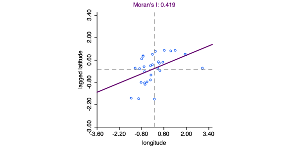

- m=4

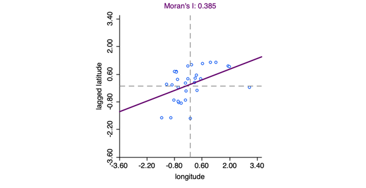

- m=5

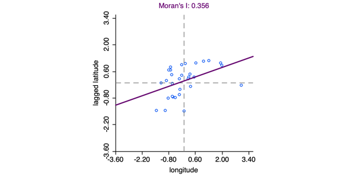

```r
location <- read.csv('location.csv')
location <- na.omit(location)
head(location)
```

```
##   city code longitude latitude
## 1 고양  540  126.7771 37.65591
## 2 고흥  262  127.2871 34.60807
## 3 공주  612  127.1211 36.44361
## 4 김제  737  126.8828 35.80058
## 5 김포  441  126.7178 37.61246
## 6 논산  615  127.1009 36.18420
```

```r
data <- read.csv('SARdata.csv')
head(data)
```

```
##   지역코드 연도 X4월.평균기온... X4월.평균최고기온... X9월.강수량.mm.
## 1       95 2013              8.1                 14.4           153.4
## 2       95 2014             12.3                 20.0            73.0
## 3       95 2015             11.3                 18.5            32.7
## 4       95 2016             12.6                 20.0            32.2
## 5       95 2017             12.1                 19.3            26.6
## 6       95 2018             11.2                 17.9            55.4
##   X7월.합계.일조시간.hr. X11월.평균.지면온도..C. 생산량
## 1                  115.9                     3.6    463
## 2                  207.1                     4.0    594
## 3                  197.7                     5.8    572
## 4                  153.9                     7.4    576
## 5                  119.9                     6.1    522
## 6                  234.6                     4.2    573
```

```r
data$x <- location$longitude
data$y <- location$latitude
head(data)
```

```
##   지역코드 연도 X4월.평균기온... X4월.평균최고기온... X9월.강수량.mm.
## 1       95 2013              8.1                 14.4           153.4
## 2       95 2014             12.3                 20.0            73.0
## 3       95 2015             11.3                 18.5            32.7
## 4       95 2016             12.6                 20.0            32.2
## 5       95 2017             12.1                 19.3            26.6
## 6       95 2018             11.2                 17.9            55.4
##   X7월.합계.일조시간.hr. X11월.평균.지면온도..C. 생산량        x        y
## 1                  115.9                     3.6    463 126.7771 37.65591
## 2                  207.1                     4.0    594 127.2871 34.60807
## 3                  197.7                     5.8    572 127.1211 36.44361
## 4                  153.9                     7.4    576 126.8828 35.80058
## 5                  119.9                     6.1    522 126.7178 37.61246
## 6                  234.6                     4.2    573 127.1009 36.18420
```

```r
# location 데이터 프레임을 다시 로드
location2 <- read.csv('./location.csv')
str(location2)  # 데이터 구조 확인
```

```
## 'data.frame':    31 obs. of  4 variables:
##  $ city     : chr  "고양" "고흥" "공주" "김제" ...
##  $ code     : int  540 262 612 737 441 615 616 129 614 556 ...
##  $ longitude: num  127 127 127 127 127 ...
##  $ latitude : num  37.7 34.6 36.4 35.8 37.6 ...
```

```r
# location 데이터 프레임에서 필요한 열만 추출
distance_matrix_data <- location2[, c("longitude", "latitude")]

# distance_matrix 계산
distance_matrix <- distm(distance_matrix_data)

# 행과 열 이름 설정
rownames(distance_matrix) <- location2$city
colnames(distance_matrix) <- location2$city
```

# 공간가중패널 회귀 : 최소 임계치 모델 하우스만 검정

```r
# 최소 임계치 설정
min_threshold <- 7115.696  # 김포와 고양 간의 거리를 최소 임계치로 설정

# 최소 가중치 행렬 생성
min_weight_matrix <- distance_matrix - min_threshold

# 음수 값을 1로 대체
min_weight_matrix[min_weight_matrix <= 0] <- 1

# 양수 값에 대한 가중치 계산
min_weight_matrix[min_weight_matrix > 0] <- 1 - (min_weight_matrix[min_weight_matrix > 0] / min_threshold)

# 대각선 0으로 설정
diag(min_weight_matrix) <- 0

# 표준화 (음수 값 방지)
row_sums <- rowSums(min_weight_matrix)
min_weight_matrix <- sweep(min_weight_matrix, 1, row_sums, FUN = "/")

# 음수 값 확인 및 제거
min_weight_matrix[min_weight_matrix < 0] <- 0

# 결과 출력
head(min_weight_matrix)
```

```
##            고양       고흥        공주        김제       김포        논산
## 고양 0.00000000 0.08635697 0.032673348 0.050662819 0.00000000 0.040034215
## 고흥 0.04301303 0.00000000 0.024984721 0.016188931 0.04248605 0.021233273
## 공주 0.03715380 0.05704026 0.000000000 0.018098238 0.03613696 0.004386984
## 김제 0.04298009 0.02757360 0.013502204 0.000000000 0.04197225 0.007316092
## 김포 0.00000000 0.08537642 0.031807988 0.049519752 0.00000000 0.039088650
## 논산 0.04109071 0.04375489 0.003959759 0.008851431 0.04008379 0.000000000
##            당신       서산        서천       양구       양양       양평
## 고양 0.01892642 0.02295607 0.042536750 0.02741501 0.04079969 0.01357429
## 고흥 0.03234101 0.03137131 0.020709776 0.04986779 0.05108670 0.04023680
## 공주 0.01561538 0.01694137 0.012512247 0.05582118 0.06313371 0.03192626
## 김제 0.02438128 0.02270161 0.004680662 0.05827665 0.06309789 0.04050669
## 김포 0.01750611 0.02137816 0.041262957 0.02924134 0.04253195 0.01463048
## 논산 0.02026676 0.02004946 0.006578783 0.05783487 0.06372236 0.03649375
##            여주        예산       용인       이천         익산       인제
## 고양 0.01899042 0.024897711 0.01218409 0.01538504 0.0465511381 0.03083477
## 고흥 0.03756509 0.028801731 0.03642306 0.03709599 0.0180282505 0.04967665
## 공주 0.02731974 0.006436371 0.02207183 0.02475395 0.0128914577 0.05664111
## 김제 0.03694877 0.018675520 0.03295864 0.03515752 0.0007322081 0.05875204
## 김포 0.01971561 0.023771362 0.01218143 0.01587420 0.0454663913 0.03261505
## 논산 0.03201422 0.012238341 0.02773768 0.02999128 0.0041107523 0.05837413
##            정선        정읍       진도       진천       철원        청주
## 고양 0.04101423 0.057482185 0.08997241 0.02441390 0.01524630 0.032072278
## 고흥 0.04171436 0.013033528 0.01059226 0.03092860 0.04973214 0.027084478
## 공주 0.04740876 0.025790922 0.06505224 0.01178488 0.05262607 0.007226598
## 김제 0.04982550 0.002641944 0.03187817 0.02524193 0.05570470 0.020044775
## 김포 0.04221893 0.056321650 0.08861593 0.02419934 0.01713017 0.031704221
## 논산 0.04826483 0.015634195 0.05125800 0.01784073 0.05531518 0.011774496
##             파주       평택        포천       포항        해남        화성
## 고양 0.000000000 0.01731015 0.008318932 0.07398237 0.086737320 0.009760425
## 고흥 0.044468855 0.03293804 0.046064325 0.03024500 0.006420561 0.036286061
## 공주 0.040419763 0.01391428 0.044043475 0.05794243 0.059713006 0.021979336
## 김제 0.045488773 0.02672819 0.049195904 0.04719611 0.027917431 0.031532347
## 김포 0.000737202 0.01674245 0.010192948 0.07438753 0.085488105 0.008727394
## 논산 0.044070520 0.02036187 0.047569735 0.05157772 0.046200567 0.027277625
##            화천
## 고양 0.02158000
## 고흥 0.04938162
## 공주 0.05321739
## 김제 0.05639049
## 김포 0.02344682
## 논산 0.05570159
```

```r
# 최소 가중치 행렬을 listw 객체로 변환
listw_min <- mat2listw(min_weight_matrix, style = "W")

data$id <- as.factor(data$지역코드)  # 지역 코드를 패널 ID로 설정
data$time <- as.factor(data$연도)    # 연도를 시간 변수로 설정

# 패널 데이터로 변환
panel_data <- pdata.frame(data, index = c("id", "time"))

# 종속 변수와 독립 변수 설정
panel_data$생산량 <- data$생산량
panel_data$기온 <- data$X4월.평균기온...
panel_data$최고기온 <- data$X4월.평균최고기온...
panel_data$강수량 <- data$X9월.강수량.mm.
panel_data$일조시간 <- data$X7월.합계.일조시간.hr.
panel_data$지면온도 <- data$X11월.평균.지면온도..C.

# 고정효과 모델 (최소 임계치)
fixed_model_min <- spml(생산량 ~ 기온 + 최고기온 + 강수량 +  일조시간 + 지면온도,
                       data = panel_data,
                       listw = listw_min,
                       model = "within",
                       effect = "individual")

# 랜덤효과 모델 (최소 임계치)
random_model_min <- spml(생산량 ~ 기온 + 최고기온 + 강수량 +  일조시간 + 지면온도,
                        data = panel_data,
                        listw = listw_min,
                        model = "random",
                        effect = "individual")

# 하우스만 검정
hausman_test <- sphtest(fixed_model_min, random_model_min)
hausman_test
```

```
##
##  Hausman test for spatial models
##
## data:  생산량 ~ 기온 + 최고기온 + 강수량 + 일조시간 +     지면온도
## chisq = 2.2988, df = 5, p-value = 0.8064
## alternative hypothesis: one model is inconsistent
```

# 공간가중패널회귀 - 최대 임계치 모델 하우스만 검정

```r
# 최대 임계치 설정
max_threshold <- 450966  # 진도와 양양 간의 거리를 최대 임계치로 설정

# 거리 행렬 생성
distance_matrix <- distm(location[, c("longitude", "latitude")])

# 최대 가중치 행렬 생성
max_weight_matrix <- ifelse(distance_matrix > max_threshold, 0, 1 - (distance_matrix / max_threshold))
diag(max_weight_matrix) <- 0

# 각 행의 합으로 표준화
row_sums <- rowSums(max_weight_matrix)
max_weight_matrix <- max_weight_matrix / row_sums

# 결과 출력
head(max_weight_matrix)
```

```
##            [,1]       [,2]       [,3]       [,4]       [,5]       [,6]
## [1,] 0.00000000 0.01177421 0.03360168 0.02628726 0.04765040 0.03060879
## [2,] 0.01994691 0.00000000 0.04487895 0.05704298 0.02067569 0.05006697
## [3,] 0.03203113 0.02525283 0.00000000 0.03852621 0.03237772 0.04319969
## [4,] 0.02834753 0.03631018 0.04358279 0.00000000 0.02886842 0.04678000
## [5,] 0.04763283 0.01219989 0.03395274 0.02676042 0.00000000 0.03099624
## [6,] 0.03029212 0.02924764 0.04484901 0.04293127 0.03068687 0.00000000
##            [,7]       [,8]       [,9]      [,10]       [,11]      [,12]
## [1,] 0.03919110 0.03755267 0.02959127 0.03573969 0.030297555 0.04136725
## [2,] 0.03470565 0.03604670 0.05079093 0.01046721 0.008781525 0.02378627
## [3,] 0.03937250 0.03892053 0.04043020 0.02566835 0.023175878 0.03381293
## [4,] 0.03796008 0.03882820 0.04814209 0.02044171 0.017949913 0.02962588
## [5,] 0.03976039 0.03818804 0.03011330 0.03499499 0.029597998 0.04092811
## [6,] 0.03845598 0.03854117 0.04382224 0.02372770 0.021419555 0.03209432
##           [,13]      [,14]      [,15]      [,16]      [,17]      [,18]
```

[output cut: 27 more lines]

```r
# 최소 가중치 행렬을 listw 객체로 변환
listw_max <- mat2listw(max_weight_matrix, style = "W")

# 고정효과 모델 (최소 임계치)
fixed_model_max <- spml(생산량 ~ 기온 + 최고기온 + 강수량 +  일조시간 + 지면온도,
                       data = panel_data,
                       listw = listw_max,
                       model = "within",
                       effect = "individual")

# 랜덤효과 모델 (최소 임계치)
random_model_max <- spml(생산량 ~ 기온 + 최고기온 + 강수량 +  일조시간 + 지면온도,
                        data = panel_data,
                        listw = listw_max,
                        model = "random",
                        effect = "individual")

# 하우스만 검정
hausman_test <- sphtest(fixed_model_max, random_model_max)
hausman_test
```

```
##
##  Hausman test for spatial models
##
## data:  생산량 ~ 기온 + 최고기온 + 강수량 + 일조시간 +     지면온도
## chisq = 2.1833, df = 5, p-value = 0.8232
## alternative hypothesis: one model is inconsistent
```

### 임계치 설정 방법을 사용한 공간 회귀 분석 - 최소 임계치, 랜덤효과

```r
random_effects_model_min <- spml(생산량 ~ 기온 + 최고기온 + 강수량 + 일조시간 + 지면온도,
                      data = panel_data,
                      listw = listw_min,
                      model = "random",
                      lag = TRUE)

# 모델 요약
summary(random_effects_model_min)
```

```
## ML panel with spatial lag, random effects, spatial error correlation
##
## Call:
## spreml(formula = formula, data = data, index = index, w = listw2mat(listw),
##     w2 = listw2mat(listw2), lag = lag, errors = errors, cl = cl)
##
## Residuals:
##    Min. 1st Qu.  Median    Mean 3rd Qu.    Max.
##     199     302     328     329     359     424
##
## Error variance parameters:
##      Estimate Std. Error t-value  Pr(>|t|)
## phi 2.1252979  0.6023511  3.5283 0.0004182 ***
## rho 0.0082638  0.0777875  0.1062 0.9153953
##
## Spatial autoregressive coefficient:
##        Estimate Std. Error t-value  Pr(>|t|)
## lambda 0.644376   0.074418  8.6589 < 2.2e-16 ***
##
## Coefficients:
##               Estimate Std. Error t-value Pr(>|t|)
## (Intercept) 135.072286  15.547480  8.6877  < 2e-16 ***
## 기온          0.219359   2.085438  0.1052  0.91623
## 최고기온      1.775277   1.570394  1.1305  0.25828
## 강수량       -0.039819   0.016229 -2.4536  0.01415 *
## 일조시간      0.057968   0.029289  1.9791  0.04780 *
## 지면온도      1.046731   1.075056  0.9737  0.33023
## ---
## Signif. codes:  0 '***' 0.001 '**' 0.01 '*' 0.05 '.' 0.1 ' ' 1
```

#### 기온, 최고 기온, 지면 온도 제외 후 다시 시행

```r
random_effects_model_min <- spml(생산량 ~ 강수량 + 일조시간,
                      data = panel_data,
                      listw = listw_min,
                      model = "random",
                      lag = TRUE)

# 모델 요약
summary(random_effects_model_min)
```

```
## ML panel with spatial lag, random effects, spatial error correlation
##
## Call:
## spreml(formula = formula, data = data, index = index, w = listw2mat(listw),
##     w2 = listw2mat(listw2), lag = lag, errors = errors, cl = cl)
##
## Residuals:
##    Min. 1st Qu.  Median    Mean 3rd Qu.    Max.
##     252     360     389     389     419     487
##
## Error variance parameters:
##     Estimate Std. Error t-value  Pr(>|t|)
## phi  2.27552    0.64187  3.5452 0.0003924 ***
## rho -0.25722    0.38482 -0.6684 0.5038698
##
## Spatial autoregressive coefficient:
##        Estimate Std. Error t-value  Pr(>|t|)
## lambda 0.760831   0.078795  9.6558 < 2.2e-16 ***
##
## Coefficients:
##               Estimate Std. Error t-value  Pr(>|t|)
## (Intercept) 117.861148   7.206141 16.3557 < 2.2e-16 ***
## 강수량       -0.039593   0.013679 -2.8944  0.003799 **
## 일조시간      0.062660   0.021762  2.8793  0.003986 **
## ---
## Signif. codes:  0 '***' 0.001 '**' 0.01 '*' 0.05 '.' 0.1 ' ' 1
```

### 임계치 설정 방법을 사용한 공간 회귀 분석 - 최대 임계치, 랜덤효과

```r
random_effects_model_max <- spml(생산량 ~ 기온 + 최고기온 + 강수량 + 일조시간 + 지면온도,
                      data = panel_data,
                      listw = listw_max,
                      model = "random",
                      lag = TRUE)

# 모델 요약
summary(random_effects_model_max)
```

```
## ML panel with spatial lag, random effects, spatial error correlation
##
## Call:
## spreml(formula = formula, data = data, index = index, w = listw2mat(listw),
##     w2 = listw2mat(listw2), lag = lag, errors = errors, cl = cl)
##
## Residuals:
##    Min. 1st Qu.  Median    Mean 3rd Qu.    Max.
##     268     373     401     402     431     498
##
## Error variance parameters:
##     Estimate Std. Error t-value Pr(>|t|)
## phi  2.30012    0.74841  3.0733 0.002117 **
## rho -0.74901    1.40605 -0.5327 0.594238
##
## Spatial autoregressive coefficient:
##        Estimate Std. Error t-value  Pr(>|t|)
## lambda  0.78376    0.17466  4.4873 7.214e-06 ***
##
## Coefficients:
##              Estimate Std. Error t-value  Pr(>|t|)
## (Intercept) 86.213820  11.237173  7.6722 1.691e-14 ***
## 기온        -0.157919   1.909442 -0.0827  0.934087
## 최고기온     0.999781   1.494110  0.6691  0.503401
## 강수량      -0.033416   0.011651 -2.8682  0.004129 **
## 일조시간     0.043002   0.020353  2.1128  0.034622 *
## 지면온도     0.660199   0.719449  0.9176  0.358805
## ---
## Signif. codes:  0 '***' 0.001 '**' 0.01 '*' 0.05 '.' 0.1 ' ' 1
```

#### 기온, 최고 기온, 지면 온도 제외 후 다시 시행

```r
random_effects_model_max <- spml(생산량 ~ 강수량 + 일조시간,
                      data = panel_data,
                      listw = listw_max,
                      model = "random",
                      lag = TRUE)

# 모델 요약
summary(random_effects_model_max)
```

```
## ML panel with spatial lag, random effects, spatial error correlation
##
## Call:
## spreml(formula = formula, data = data, index = index, w = listw2mat(listw),
##     w2 = listw2mat(listw2), lag = lag, errors = errors, cl = cl)
##
## Residuals:
##    Min. 1st Qu.  Median    Mean 3rd Qu.    Max.
##     294     403     432     432     462     530
##
## Error variance parameters:
##     Estimate Std. Error t-value  Pr(>|t|)
## phi  2.45079    0.72045  3.4018 0.0006695 ***
## rho -0.99900    1.00204 -0.9970 0.3187831
##
## Spatial autoregressive coefficient:
##        Estimate Std. Error t-value  Pr(>|t|)
## lambda 0.842692   0.085105  9.9018 < 2.2e-16 ***
##
## Coefficients:
##               Estimate Std. Error t-value  Pr(>|t|)
## (Intercept) 77.1041359  6.5884398 11.7029 < 2.2e-16 ***
## 강수량      -0.0300048  0.0096846 -3.0982  0.001947 **
## 일조시간     0.0425281  0.0145111  2.9307  0.003382 **
## ---
## Signif. codes:  0 '***' 0.001 '**' 0.01 '*' 0.05 '.' 0.1 ' ' 1
```

### AIC & BIC 비교

```r
models <- list(random_effects_model_min, random_effects_model_max)
model_names <- c("minimum","maximum")

for (i in seq_along(models)) {
  residuals <- residuals(models[[i]])
  residual_sum_sq <- sum(residuals^2)
  n_obs <- length(residuals)
  n_params <- length(coef(models[[i]]))
  log_likelihood <- -n_obs / 2 * (log(2 * pi) + log(residual_sum_sq / n_obs) + 1)
  bic <- -2 * log_likelihood + n_params * log(n_obs)
  aic <- -2 * log_likelihood + 2 * n_params

  cat("Model:", model_names[i], "\n")
  cat("BIC:", bic, "\n")
  cat("AIC:", aic, "\n\n")
}
```

```
## Model: minimum
## BIC: 4597.926
## AIC: 4586.716
##
## Model: maximum
## BIC: 4662.148
## AIC: 4650.938
```

#### 최소 임계치 행렬 모델의 BIC, AIC 값이 최대 임계치 행렬 모델보다 낮으므로 더 좋은 모델이다.

### 모델의 적합도 판정 - 최소 임계치, 랜덤 효과

```r
Y_hat <- fitted(random_effects_model_min)

Y <- panel_data$생산량

# 평균 계산
Y_mean <- mean(Y)

# 중심화된 벡터 계산
Y_centered <- Y - Y_mean
Y_hat_centered <- Y_hat - mean(Y_hat)

# 분자: (Y_centered' %*% Y_hat_centered)^2
numerator <- sum(Y_centered * Y_hat_centered)^2

# 분모: (Y_centered' %*% Y_centered) * (Y_hat_centered' %*% Y_hat_centered)
denominator <- sum(Y_centered^2) * sum(Y_hat_centered^2)

# R-squared 계산
R_squared <- numerator / denominator

# 결과 출력
cat("R-squared:", R_squared, "\n")
```

```
## R-squared: 0.006669994
```

### 모델의 적합도 판정 - 최대 임계치, 랜덤 효과

```r
Y_hat <- fitted(random_effects_model_max)

# 중심화된 벡터 계산
Y_centered <- Y - Y_mean
Y_hat_centered <- Y_hat - mean(Y_hat)

# 분자: (Y_centered' %*% Y_hat_centered)^2
numerator <- sum(Y_centered * Y_hat_centered)^2

# 분모: (Y_centered' %*% Y_centered) * (Y_hat_centered' %*% Y_hat_centered)
denominator <- sum(Y_centered^2) * sum(Y_hat_centered^2)

# R-squared 계산
R_squared <- numerator / denominator

# 결과 출력
cat("R-squared:", R_squared, "\n")
```

```
## R-squared: 0.007085577
```

#### 최소, 최대 임계치 모델들에 대한 결정 계수 값이 0.1 이하로 너무 작아 모델의 적합도가 매우 낮다고 봄

### Moran’s I test - 최소 임계치, 랜덤효과

```r
production <- panel_data %>% group_by(id) %>% summarise(생산량 = mean(생산량))

production_values <- production$생산량

min_moran_test <- moran.test(production_values, listw_min)

min_moran_test
```

```
##
##  Moran I test under randomisation
##
## data:  production_values
## weights: listw_min
##
## Moran I statistic standard deviate = 0.6918, p-value = 0.2445
## alternative hypothesis: greater
## sample estimates:
## Moran I statistic       Expectation          Variance
##     -0.0185643512     -0.0333333333      0.0004557585
```

### Moran’s I test - 최대 임계치, 랜덤효과

```r
max_moran_test <- moran.test(production_values, listw_max)

max_moran_test
```

```
##
##  Moran I test under randomisation
##
## data:  production_values
## weights: listw_max
##
## Moran I statistic standard deviate = -0.44113, p-value = 0.6704
## alternative hypothesis: greater
## sample estimates:
## Moran I statistic       Expectation          Variance
##     -0.0391075379     -0.0333333333      0.0001713408
```

# 패널 회귀 모형

## 하우스만 검정

```r
# 고정효과 모형 적합
fe_model <- plm(생산량 ~ 기온 + 최고기온 + 강수량 + 일조시간 + 지면온도, data = panel_data,model = "within")
#랜덤효과 모형 적합
re_model <- plm(생산량 ~ 기온 + 최고기온 + 강수량 + 일조시간 + 지면온도, data=panel_data,model = "random")
# 하우스만 검정
hausman_test <- phtest(fe_model, re_model)
hausman_test
```

```
##
##  Hausman Test
##
## data:  생산량 ~ 기온 + 최고기온 + 강수량 + 일조시간 +  ...
## chisq = 1.3061, df = 5, p-value = 0.9343
## alternative hypothesis: one model is inconsistent
```

결과 : p-value가 0.9343이므로 랜덤효과 효과 모델을 사용하는 것이 더 좋음

# 패널 회귀분석 - 랜덤효과

```r
panel <- plm(생산량 ~ 기온 + 최고기온 + 강수량 + 일조시간 + 지면온도,  data = panel_data, model = "random")
summary(panel)
```

```
## Oneway (individual) effect Random Effect Model
##    (Swamy-Arora's transformation)
##
## Call:
## plm(formula = 생산량 ~ 기온 + 최고기온 + 강수량 +
##     일조시간 + 지면온도, data = panel_data, model = "random")
##
## Balanced Panel: n = 31, T = 10, N = 310
##
## Effects:
##                  var std.dev share
## idiosyncratic 590.11   24.29 0.424
## individual    801.62   28.31 0.576
## theta: 0.7381
##
## Residuals:
##      Min.   1st Qu.    Median   3rd Qu.      Max.
## -103.4733  -14.9245    2.2772   17.1848   54.7600
##
## Coefficients:
##               Estimate Std. Error z-value  Pr(>|z|)
## (Intercept) 406.153229  16.909340 24.0195 < 2.2e-16 ***
## 기온          4.320584   2.134344  2.0243   0.04294 *
## 최고기온      1.278717   1.537340  0.8318   0.40554
## 강수량       -0.094003   0.018559 -5.0652 4.079e-07 ***
## 일조시간      0.139835   0.033429  4.1830 2.877e-05 ***
## 지면온도      2.450550   1.213495  2.0194   0.04344 *
## ---
## Signif. codes:  0 '***' 0.001 '**' 0.01 '*' 0.05 '.' 0.1 ' ' 1
##
## Total Sum of Squares:    270710
## Residual Sum of Squares: 184960
## R-Squared:      0.31674
## Adj. R-Squared: 0.3055
## Chisq: 140.926 on 5 DF, p-value: < 2.22e-16
```

- 검정결과 유의하지 않은 최고기온을 제외하고 다시 검정 수행

  ```r
  panel <- plm(생산량 ~ 기온  + 강수량 + 일조시간 + 지면온도,  data = panel_data, model = "random")
  summary(panel)
  ```

  ```
  ## Oneway (individual) effect Random Effect Model
  ##    (Swamy-Arora's transformation)
  ##
  ## Call:
  ## plm(formula = 생산량 ~ 기온 + 강수량 + 일조시간 +
  ##     지면온도, data = panel_data, model = "random")
  ##
  ## Balanced Panel: n = 31, T = 10, N = 310
  ##
  ## Effects:
  ##                  var std.dev share
  ## idiosyncratic 594.80   24.39 0.411
  ## individual    853.09   29.21 0.589
  ## theta: 0.7447
  ##
  ## Residuals:
  ##      Min.   1st Qu.    Median   3rd Qu.      Max.
  ## -102.1771  -14.7506    2.1686   16.7589   55.3516
  ##
  ## Coefficients:
  ##               Estimate Std. Error z-value  Pr(>|z|)
  ## (Intercept) 412.825038  14.811968 27.8710 < 2.2e-16 ***
  ## 기온          5.789698   1.228876  4.7114 2.460e-06 ***
  ## 강수량       -0.094417   0.018485 -5.1079 3.258e-07 ***
  ## 일조시간      0.136766   0.033163  4.1241 3.723e-05 ***
  ## 지면온도      2.367318   1.208900  1.9582    0.0502 .
  ## ---
  ## Signif. codes:  0 '***' 0.001 '**' 0.01 '*' 0.05 '.' 0.1 ' ' 1
  ##
  ## Total Sum of Squares:    269560
  ## Residual Sum of Squares: 184310
  ## R-Squared:      0.31627
  ## Adj. R-Squared: 0.3073
  ## Chisq: 141.08 on 4 DF, p-value: < 2.22e-16
  ```

## 결과

  회귀 계수 (Coefficients)
  - 기온 (Temperature): 5.789698, 기온이 1도 증가할 때 생산량이 5.79 증가하는 것으로 나타남.
    - p-value: 2.460e-06, 기온의 효과가 통계적으로 매우 유의미함.
  - 강수량 (Rainfall): -0.094417, 강수량이 1mm 증가할 때 생산량이 0.094 감소하는 것으로 나타남.
    - p-value: 3.258e-07, 강수량의 효과가 통계적으로 매우 유의미함.
  - 일조시간 (Sunshine Hours): 0.136766, 일조시간이 1시간 증가할 때 생산량이 0.137 증가하는 것으로 나타남.
    - p-value: 3.723e-05, 일조시간의 효과가 통계적으로 유의미함.
  - 지면온도 (Ground Temperature): 2.367318, 지면온도가 1도 증가할 때 생산량이 2.37 증가하는 것으로 나타남.
    - p-value: 0.0502 (유의수준 0.05에 근접). 모델 성능 지표
    - 총 제곱합 (Total Sum of Squares): 269560
    - 잔차 제곱합 (Residual Sum of Squares): 184310
    - R-Squared: 0.31627, 설명 변수가 전체 변동성의 약 31.63%를 설명함.
    - Adj. R-Squared: 0.3073, 조정된 결정 계수.
    - Chisq: 141.08, 자유도 4, p-value: < 2.22e-16, 모델 전체가 통계적으로 유의미함을 나타냄.

## AIC & BIC 계산

```r
# 로그-우도 계산
log_likelihood <- -n_obs / 2 * (log(2 * pi) + log(residual_sum_sq / n_obs) + 1)

# BIC 계산
bic <- -2 * log_likelihood + n_params * log(n_obs)

# AIC 계산
aic <- -2 * log_likelihood + 2 * n_params

# 결과 출력
cat("BIC:", bic, "\n")
```

```
## BIC: 4662.148
```

```r
cat("AIC:", aic, "\n")
```

```
## AIC: 4650.938
```

- 결론 : BIC&AIC는 공간가중패널회귀가 더 낮지만 모델의 설명력을 나타내주는 R-Squared 값이 일반패널모형에서 압도적으로 높기 때문에 공간가중패널회귀에 비해 일반패널회귀모형이 유의한 것을 알 수 있음

# 비교 - 일반 선형회귀 시행

```r
# 일반 선형회귀 모델 적합
ols_model <- lm(생산량 ~ X4월.평균기온... + X4월.평균최고기온... + X9월.강수량.mm. + X7월.합계.일조시간.hr. + X11월.평균.지면온도..C.,
data = data)

# 일반 선형회귀 모델 회귀분석 결과 요약
summary(ols_model)
```

```
##
## Call:
## lm(formula = 생산량 ~ X4월.평균기온... + X4월.평균최고기온... +
##     X9월.강수량.mm. + X7월.합계.일조시간.hr. + X11월.평균.지면온도..C.,
##     data = data)
##
## Residuals:
##      Min       1Q   Median       3Q      Max
## -121.630  -23.644    0.018   24.537   90.735
##
## Coefficients:
##                          Estimate Std. Error t value Pr(>|t|)
## (Intercept)             397.30499   19.85030  20.015  < 2e-16 ***
## X4월.평균기온...         -1.73466    1.84740  -0.939    0.348
## X4월.평균최고기온...      3.46738    0.77543   4.472 1.10e-05 ***
## X9월.강수량.mm.          -0.12869    0.02705  -4.758 3.02e-06 ***
## X7월.합계.일조시간.hr.    0.22269    0.04817   4.623 5.59e-06 ***
## X11월.평균.지면온도..C.   6.63202    1.37319   4.830 2.17e-06 ***
## ---
## Signif. codes:  0 '***' 0.001 '**' 0.01 '*' 0.05 '.' 0.1 ' ' 1
##
## Residual standard error: 37.98 on 304 degrees of freedom
## Multiple R-squared:  0.2501, Adjusted R-squared:  0.2377
## F-statistic: 20.27 on 5 and 304 DF,  p-value: < 2.2e-16
```

-> 평균기온 유의 X -> 제외하고 다시 선형회귀

```r
# 일반 선형회귀 모델 적합
ols_model <- lm(생산량 ~  X4월.평균최고기온... + X9월.강수량.mm. + X7월.합계.일조시간.hr. + X11월.평균.지면온도..C.,
data = data)

# 일반 선형회귀 모델 회귀분석 결과 요약
summary(ols_model)
```

```
##
## Call:
## lm(formula = 생산량 ~ X4월.평균최고기온... + X9월.강수량.mm. +
##     X7월.합계.일조시간.hr. + X11월.평균.지면온도..C.,
##     data = data)
##
## Residuals:
##      Min       1Q   Median       3Q      Max
## -118.014  -24.498    0.312   25.242   90.946
##
## Coefficients:
##                          Estimate Std. Error t value Pr(>|t|)
## (Intercept)             390.47675   18.46672  21.145  < 2e-16 ***
## X4월.평균최고기온...      3.15389    0.69974   4.507 9.37e-06 ***
## X9월.강수량.mm.          -0.12675    0.02696  -4.701 3.92e-06 ***
## X7월.합계.일조시간.hr.    0.20401    0.04386   4.652 4.92e-06 ***
## X11월.평균.지면온도..C.   5.92320    1.14685   5.165 4.35e-07 ***
## ---
## Signif. codes:  0 '***' 0.001 '**' 0.01 '*' 0.05 '.' 0.1 ' ' 1
##
## Residual standard error: 37.97 on 305 degrees of freedom
## Multiple R-squared:  0.2479, Adjusted R-squared:  0.238
## F-statistic: 25.13 on 4 and 305 DF,  p-value: < 2.2e-16
```

```r
# 잔차 계산
residuals <- residuals(ols_model)
residual_sum_sq <- sum(residuals^2)
n_obs <- length(residuals)
n_params <- length(coef(ols_model))

# 로그-우도 계산
log_likelihood <- -n_obs / 2 * (log(2 * pi) + log(residual_sum_sq / n_obs) + 1)

# BIC 계산
bic <- -2 * log_likelihood + n_params * log(n_obs)

# AIC 계산
aic <- -2 * log_likelihood + 2 * n_params

# 결과 출력
cat("BIC:", bic, "\n")
```

```
## BIC: 3158.252
```

```r
cat("AIC:", aic, "\n")
```

```
## AIC: 3139.569
```

# 결과

공간적 자기상관을 고려하지 않은 패널 회귀모형에서 가장 잘 적합함을 알 수 있었음.

그러나 전체적으로 설명력이 좋은 편은 아님.